# Obligationsmarkedet

Betalingsrækker, pris og rente

Niklas Lehmann Jensen

## Introduktion

#### Dagens spørgsmål

- Hvordan bliver en obligations kontrakt til en **betalingsrække**?
- Hvordan binder **effektiv rente** pris og betalinger sammen?
- Hvad betaler investor faktisk ved handel?
- Hvorfor bevæger kurs og markedsrente sig modsat?

#### Læringsmål

Efter kapitlet kan I:

- skelne mellem **hovedstol, kupon, afdrag, ydelse og kurs**
- forklare stående lån, annuitetslån og serielån
- prisfastsætte simple nulkupon- og kuponobligationer
- skelne mellem **clean price, dirty price og vedhængende rente**
- forklare reinvesteringsrisiko, prisrisiko og pull-to-par

## Tre afdragsprofiler

#### Stående lån samler hovedstolen ved udløb

- Hovedstol: **1.000.000 kr.**
- Årlig kupon: **4% = 40.000 kr.**
- År 1–9: kun rente
- År 10: rente + hovedstol = **1.040.000 kr.**

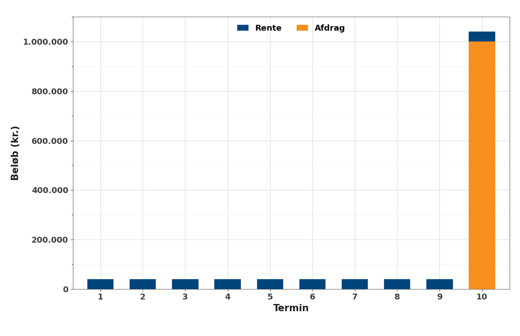

#### Annuitetslånet holder ydelsen konstant

- Fast årlig ydelse: **123.291 kr.**
- Renteandelen falder med restgælden
- Afdragsandelen stiger tilsvarende
- Hovedstolen kommer tidligere retur end ved et stående lån

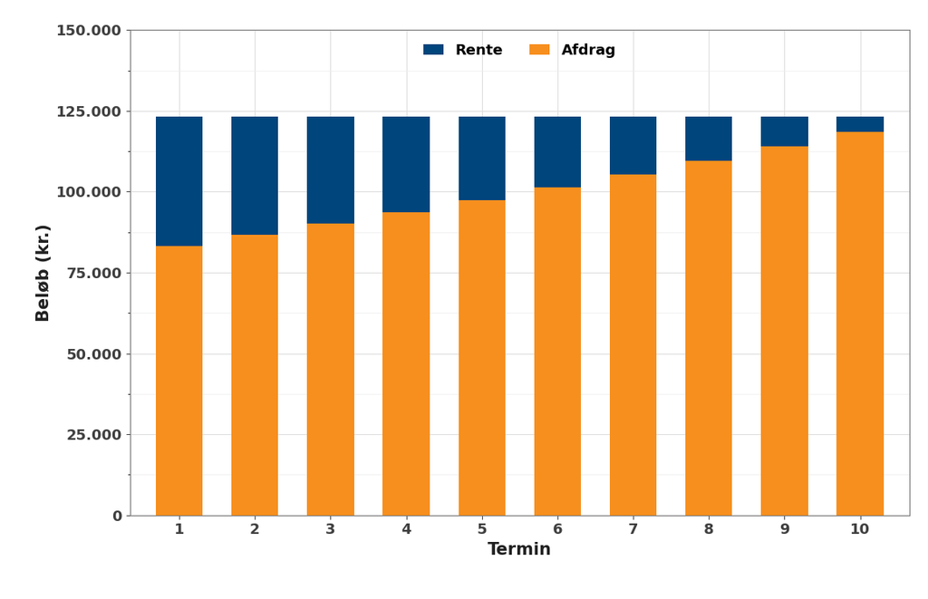

#### Serielånet holder afdraget konstant

- Fast årligt afdrag: **100.000 kr.**
- Rente: 40.000 kr. i år 1 → 4.000 kr. i år 10
- Ydelse: 140.000 kr. → 104.000 kr.
- Hurtig og systematisk nedbringelse af gælden

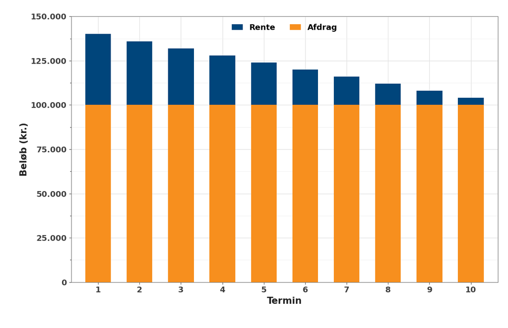

#### Samme lån — forskellig timing

| Profil | Hvad er konstant? | Hvornår kommer hovedstolen retur? | Ydelsesforløb |
| --- | --- | --- | --- |
| Stående | Rentebetalingen | Ved udløb | Lav, så stort slutbeløb |
| Annuitet | Samlet ydelse | Gradvist | Konstant |
| Serie | Afdraget | Hurtigst | Faldende |

**Indsigt**

Betalingernes **timing** påvirker både prisfølsomhed og reinvesteringsrisiko.

## Betalingsrække og nutidsværdi

#### En obligation er fremtidige betalinger

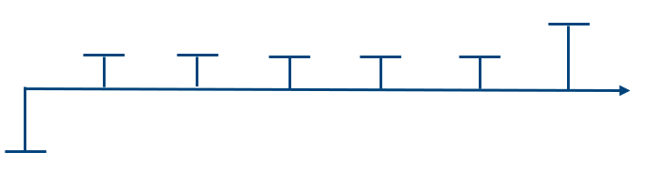

#### Nutidsværdi gør tidspunkter sammenlignelige

$$PV=\frac{A}{(1+r)^t},
\qquad
d_t=\frac{1}{(1+r)^t}$$

Ved $m$ rentetilskrivninger om året:

$$d(t)=\left(1+\frac{r}{m}\right)^{-mt}$$

**Indsigt**

Højere rente eller længere ventetid giver lavere nutidsværdi.

#### Effektiv rente rammer den observerede pris

$$P=\sum_{t=1}^{N}\frac{CF_t}{(1+y)^t}$$

**Definition**

Den **effektive rente** er den ene rente, der får betalingsrækkens nutidsværdi til at være lig markedsprisen.

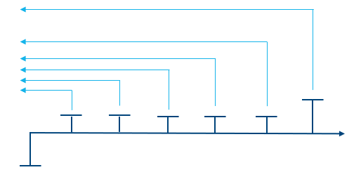

## Handel: fra kurs til afregning

#### Kursen er pris pr. 100 nominel

| Obligationsnavn | Fondskode | Kurs | Kupon (%) | Cirk. (mio.) | Terminer | Udløb |
| --- | --- | --- | --- | --- | --- | --- |
| 0 STA GOV 2024 | DK0009819666 | 99,33 | 0,00 | 2.660 | 1 | 2024 |
| 4,5 STA GOV 2039 | DK0009922320 | 127,80 | 4,50 | 104.250 | 1 | 2039 |

$$KV=H\cdot\frac{K}{100}$$

- Kurs **127,80** = 127,80 kr. pr. 100 kr. nominel
- $H=100.000$ kr. giver $KV=127.800$ kr.
- Danske statsobligationer har typisk én termin årligt
- 4,5% med to terminer giver 2,25% pr. termin

#### Vedhængende rente tilhører sælger

$$v=\frac{r\cdot H\cdot D}{n\cdot DT}$$

$$v=\frac{0{,}045\cdot100.000\cdot302}{1\cdot365}
=3.723{,}29$$

- Handel: 10. september 2024
- Valør: 12. september 2024 (**T+2**)
- Næste termin: 15. november 2024

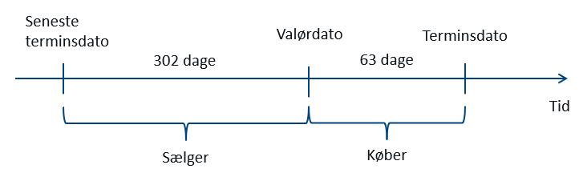

#### Dirty price er det, der betales

**Definition**

**Dirty price = clean price + vedhængende rente**

$$127{,}800+3{,}723=131{,}523$$

Afregningsbeløb:

$$127.800+3.723{,}29=131.523{,}29\text{ kr.}$$

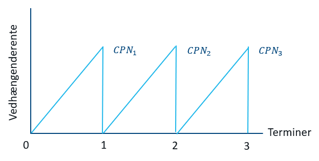

## Nulkupon og kupon

#### Nulkuponobligationen har én betaling

Ingen løbende kuponer — kun én betaling ved udløb:

$$P=\frac{FV}{(1+y)^N}
\qquad\Longrightarrow\qquad
P=\frac{100}{1{,}05^3}=86{,}38$$

(tre år, $FV=100$, $y=5\%$)

**Important**

Ved negative renter kan en nulkuponobligation handle **over** pari.

#### En nulkuponrente kan isoleres direkte

$$980.000=\frac{1.000.000}{(1+y)^{10}}$$

$$y=\left(\frac{1.000.000}{980.000}\right)^{1/10}-1
=0{,}2022\%$$

**Indsigt**

Afkastet kommer kun fra kurs 98 i dag til kurs 100 ved udløb.

#### Kuponobligationen er en sum af nutidsværdier

$$P=\sum_{t=1}^{N}\frac{C}{(1+y)^t}+\frac{H}{(1+y)^N}$$

Samme kupon hvert år giver genvejen:

$$P=C\cdot\frac{1-(1+y)^{-N}}{y}+\frac{H}{(1+y)^N}$$

- Kurs 98, 10 år, 4% kupon → $y\approx4{,}25\%$
- $y$ findes normalt numerisk, fx i Excel

## Effektiv rente er ikke et løfte

#### Kuponer skal genplaceres for at realisere YTM

- Effektiv rente: cirka **4,25%**
- Årlig kupon: **40.000 kr.**
- Slutværdi ved genplacering til 4,25%: **1.485.849 kr.**
- Heraf rente på genplacerede kuponer: cirka **85.849 kr.**

**Important**

Lavere genplaceringsrente giver lavere realiseret afkast end YTM.

#### Reinvesteringsrisiko og prisrisiko er forskellige

- **Reinvesteringsrisiko:** fremtidige kuponer kan kun genplaceres til en ukendt rente
- Størst ved store løbende betalinger og lang horisont
- **Prisrisiko:** salg før udløb kan ske til en anden kurs
- Størst når betalingerne ligger langt ude i fremtiden

**Indsigt**

Høj kupon øger reinvesteringsrisikoen; lav kupon og lang løbetid øger typisk prisfølsomheden.

## Kurs, rente og tid

#### Kurs og markedsrente bevæger sig modsat

**Indsigt**

Rente ↑ → gammel fast betalingsrække mindre attraktiv → kurs ↓

- Rente = kupon → kurs omkring 100
- Rente > kupon → kurs under 100
- Rente < kupon → kurs over 100

#### Markedsrenten flytter gamle obligationer væk fra pari

- **Discount:** kurs < 100, rente > kupon
- **Pari:** kurs ≈ 100, rente ≈ kupon
- **Præmie:** kurs > 100, rente < kupon
- Kurs > 100 bliver centralt for konverterbare realkreditobligationer

[figure not shown]

#### Lang løbetid giver større prisfølsomhed

- Samme hovedstol: 1.000 kr.
- Samme kupon: 10%
- A: 30 år; B: 1 år
- Rente 10% → 15%:
  - A: 1.000 → **671,70**
  - B: 1.000 → **956,52**

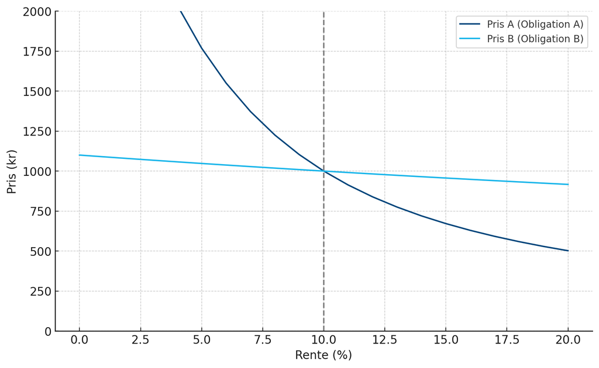

#### Pull-to-par virker selv ved uændret rente

30-årig nulkupon, $y=5\%$:

$$P_0=\frac{100}{1{,}05^{30}}=23{,}14$$

Fem år senere:

$$P_5=\frac{100}{1{,}05^{25}}=29{,}53$$

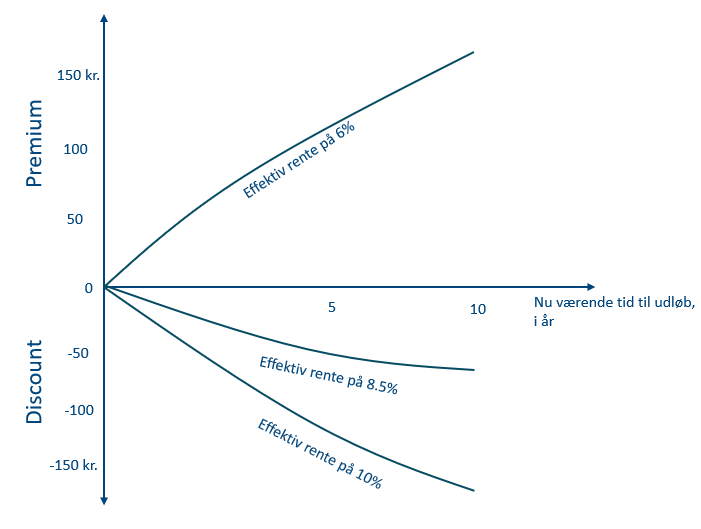

## Afrunding

#### The Takeaways

1. Afdragsprofilen bestemmer **betalingsrækkens timing**.
2. Pris er nutidsværdi; effektiv rente er den ene rente, der rammer markedsprisen.
3. Ved handel betales **dirty price = clean price + vedhængende rente**.
4. Kurs og markedsrente bevæger sig modsat.
5. Realiseret afkast afhænger også af genplacering, salgskurs og tid.

#### Øvelse: fra kontrakt til afkast

En 10-årig statsobligation har 3% årlig kupon og termin 15. september.

1. Tegn betalingsrækken for nominel 100.000 kr.
2. Find kursværdien ved en oplyst markedskurs.
3. Beregn vedhængende rente fra valørdagen.
4. Find effektiv rente numerisk i Excel.
5. Forklar, hvad der skal til for at realisere den beregnede rente.